# Data Wrangling with R

MSDA - Bootcamp 2025 Summer

KT Wong

kwanto@hku.hk

Faculty of Social Sciences, HKU

2025-08-08

The materials in this topic are drawn from Imai and Williams (2022), Wickham and Grolemund (2023), Wickham (2019) and Wickham (2016) as well as other sources, including Princeton Sociology Methods Camp 2023. The materials are for educational purposes only.

## Introduction

- Data wrangling is the process of transforming and cleaning data to make it suitable for analysis
  - it is an essential step in the data analysis process
  - it involves a variety of tasks, including:
    - loading data
    - exploring data
    - subsetting data
    - manipulating data
    - recoding variables
    - reshaping data
- we use the `tidyverse` package - a collection of packages for data manipulation and visualization
  - the core of tidyverse package for data manipulation is the `dplyr` package
  - also use the `tidyr` package for reshaping data later

## Loading Data

- The first step in any data analysis is to load the data into R
  - the data can be in a variety of formats
  - the most common formats are CSV, Excel, and SPSS
  - the `readr` package is part of the tidyverse and is used to read data into R

```r
#install.packages("tidyverse")
library(tidyverse)


# check your working directory
getwd()

## read data file

addh<- read_csv("https://raw.githubusercontent.com/kwan-MSDA/Bootcamp_2024/main/dataset/addhealthfake.csv")
```

## Add health dataset

- Here are some details about the [dataset](https://addhealth.cpc.unc.edu/data/#public-use)
  - The National Longitudinal Study of Adolescent to Adult Health (Add Health)
  - a longitudinal study of a nationally representative sample of adolescents in **grades 7-12** in the United States during the 1994-95 school year (Wave I)
  - The Add Health cohort has been followed into young adulthood with four in-home interviews for Wave I-IV by 2008
    - the Wave V conducted during 2016-2018 included a mixed-mode survey
  - respondents’ social, economic, psychological, and physical well-being
    - along with contextual data on the family, neighborhood, community, school, friendships, peer groups, and romantic relationships
  - study developmental trajectories of health and risk behaviors throughout the life course

## Explore data

- The dataset used here is a subset of the Add Health dataset
  - 3000 observations and 11 variables
- After the dataset is loaded in R, it is important to explore the data to understand its structure and content
- The following steps are recommended to explore the data:
  - check the data types of key variables
  - check the dimensions of the data
  - look at a few rows and variables

```r
class(addh$age)

class(addh$gender)

class(addh$love)
```

## Explore data

- For more information on the dataset,
  - summary(): numeric summaries
  - str(): data types and sample data
  - colnames() or names(): names of columns/variables
  - dim(): dimensions
  - View(): view all data in RStudio viewer
  - head(): top 6 rows
  - tail(): bottom 6 rows

## Explore data

```r
str(addh)
```

```r
head(addh, n=5)
```

```r
tail(addh, n=5)
```

```r
colnames(addh)
```

## Explore data

- To get information about one variable, use the following functions:
  - table(): get a table summarizing counts
  - unique(): get the unique responses for a variable
  - sort(): sort the numerically (or alphabetically)
  - hist(): produce a histogram

```r
table(addh$gender)
```

```r
table(addh$age)
```

```r
sort(unique(addh$age))
```

## Subset data

- let us recap by using the base R subsetting syntax with [row index, column index]

```r
# get first column, rows 1 through 3
addh[1:3,1]
```

- **Exercise**: How would you subset the observation in the third row and the fifth column?
- we can use `-` to exclude rows or columns

```r
# get everything besides first row
addh[-1, ]
```

## Exercises

- Suppose that you want to know a few things from the dataset:
  - What’s the median income of this sample? What’s the mean age?
  - What are the answer choices for debt?
  - On average, do the young adults surveyed think money, no cheating, or love is more important in a relationship?
- hint: for simple calculations, you can use the base R functions mean(), median(), and table()

```r
median(addh$income)

mean(addh$age)

unique(addh$debt)
```

```r
# as a precursor to the next section, we can use dplyr to do the same thing

library(dplyr)

addh %>%
  summarise(mean_money = mean(money),
            mean_nocheating = mean(nocheating),
            mean_love = mean(love)
            )
```

## Data Manipulation

- The `dplyr` package is part of the tidyverse and is used for data manipulation
- dplyr functions include:
  - `filter()`: subset rows
  - `select()`: subset columns
  - `mutate()`: create new variables
  - `summarise()`: summarize data
  - `arrange()`: sort data
  - `group_by()`: group data
- very important function: pipe operator `%>%` from the **magrittr** package
  - allows you to chain functions together
- basic structure of the dplyr functions
  - function(dataframe, operation 1 to perform, opertaion 2 to perform,…)

## Data Manipulation

*`dplyr` - select*

- it can be used with [operations](https://dplyr.tidyverse.org/reference/select.html), like
  - `starts_with()`
  - `ends_with()`
  - `contains()`
  - `matches()`
  - etc…

```r
pay_variables <- select(addh, contains("pay"))

head(pay_variables, 5)
```

## Data Manipulation

*`dplyr` - filter*

- filter rows based on conditions

```r
nodebt_income <- filter(addh, debt == "nodebt" & income >= 10000)

nrow(nodebt_income)
```

```r
nomissing_income <- filter(addh, !is.na(income)) # only keep obs that are NOT (!) na

nrow(nomissing_income)

nomissing_income2 <- drop_na(addh, income) # alternate function from tidyr

nrow(nomissing_income2)
```

## Data Manipulation

*`dplyr` - arrange*

- sort data based on one or more columns
- task: find the two observations who think money is extremely important for a relationship (10 on **money**) but who pay for the fewest percentage of dates (**paypercent**)

```r
addh %>%
  filter(money == 10) %>%
  arrange(paypercent) %>%
  head(2)
```

```r
addh %>%
  filter(money == 10) %>%
  arrange(paypercent, gender)
```

## Data Manipulation

*`dplyr` - mutate*

- create new variables added to the dataset
- task: add a variable with the average rating for nocheating, money, and love’s importance for a relationship (sum divided by 3) and another variable that logs that rating

```r
addh<- mutate(addh,
              rateavg=(love + money + nocheating)/3,
              rateavglog=log(rateavg))

head(addh, 5)
```

- Caution
  - using the same column name or same object name, you overwrite the original object or column

## Data Manipulation

*`dplyr` - group_by and summarise*

- group data by one or more variables and then summarize the data according to the groups
- task: find the average “not cheating importance” for different gender

```r
addh %>%
  group_by(gender) %>%
  summarize(mean_nocheating = mean(nocheating))
```

- **summarise** has a number of operations for creating summary statistics
  - mean(), median(), min(), max(), sd(), n(), n_distinct(), first, last, etc…

## Exercises

1. Exercise one
   - the number of females and males by debt status
   - the percentage in each (debt x gender) category as a fraction of all observations
   - the number of distinct ratings of love’s importance in each of these debt x gender categories

```r
addh %>%
  group_by(gender, debt) %>%
  summarize(percentage = n()/nrow(addh),
            n_distinct_love = n_distinct(love))
```

## Exercises

2. Exercise two
- Group the data by gender and debt status first
  - Find the average rating of love, no cheating, and money’s importance for a relationship in each group
  - Arrange the groups by their rating of money’s importance to a relationship from the highest to rating to the lowest rating

```r
addh %>%
  group_by(gender, debt) %>%
  summarize(mean_love = mean(love),
            mean_nocheating = mean(nocheating),
            mean_money = mean(money)) %>%
  arrange(desc(mean_money))
```

## Recoding Variables

- Recoding variables is a common task in data analysis for social science research
  - convert a variable from one format to another
  - create a new variable based on the values of an existing variable (or of multiple existing variables)
- some typical recoding tasks
  - convert a continuous variable to a categorical variable
  - convert a categorical variable to a continuous variable
  - create categorical variables based on conditions
- Our focus
  - data types
  - logical statements
  - case_when() function

## Recoding Variables

*`changing data types`*

- use the `mutate()` function to change the data type of a variable
  - `as.character()`
  - `as.numeric()`
  - `as.factor()`
  - `as.integer()`
  - `as.logical()`

```r
addh2 <- addh %>%
            mutate(
               age = as.character(age),
               debt = as.factor(debt)
               )

head(addh2, 3)
```

## Recoding Variables

*`create a vector`*

- use c to string together the elements

```r
agevec<- c(18, 21, 23, 25, 27, 30)

agevec
```

```r
class(agevec)
```

```r
gendervec <- c("male", "female", "other", "female", "female", "male")

gendervec
```

```r
class(gendervec)
```

## Recoding Variables

*`create a vector`*

- Elements in a vector need to be of the same type, otherwise, type coercion happens

```r
c(28, "28", TRUE)
```

```r
c(28, "28", TRUE) %>% class()
```

```r
c(1,2,3, TRUE, FALSE)

c(1,2,3, TRUE, FALSE) %>% class()
```

## Recoding Variables

*`data types`*

- convert from one type to another using the following functions:
  - `as.numeric()`
  - `as.character()`
  - `as.factor()`

```r
as.character(agevec)
```

```r
as.numeric(gendervec)
```

## Recoding Variables

*`data types`*

- Vectors can have a factor type
  - looks like a character vector
  - but is actually a number under the hood (“labelled data”)

```r
genderfactorvec<- factor(gendervec,
                         levels=c("male", "female", "other"))

genderfactorvec
```

```r
class(genderfactorvec)
```

```r
as.numeric(genderfactorvec)
```

## Recoding Variables

*`create a vector`*

- there are functions to help you create the vector more efficiently:
  1. `rep`: repeat the same thing multiple times
  2. `seq`: create a sequence of numbers
  3. `paste`: stick together character and numeric info
  4. `sample`: for vectors where we want to randomly sample from some larger pool

```r
rep(1, 5)
```

```r
seq(from=1997, to=2025, by=5)
```

```r
paste("age", seq(from=22, to=30, by=1),
      sep="_")
```

## Recoding Variables

*`from vectors to dataframes`*

- One way to create a dataframe
  - use `bind_cols()` to attach same-length vectors together as columns in a tibble
  - Vectors can be different types

```r
bind_cols(age=agevec, gender=gendervec)
```

## Exercises

```r
addh2<- addh %>%
            mutate(gender=factor(gender,
                                 levels=c("male", "female")
                                 )
               )

str(addh2$gender)

vec1<- as.character(addh2$gender)
vec2<- as.numeric(addh2$gender)
```

- convert the variable `gender` in addh to a factor variable
- what happens if you try to convert the variable to character by using as.character after the factor conversion
- what happens if you try to convert the variable to number by using as.numeric after the factor conversion

## Recoding Variables

*`Matrices in R`*

- A matrix is a two-dimensional array
  - all elements must be of the same type
  - can be created using the matrix() function
  - can be created from a vector using the dim() function

```r
matrix1<- matrix(1:15, nrow=3, ncol=5)

matrix1
```

## Recoding Variables

*`Matrices in R - some basic operations`*

```r
dim(matrix1)
```

```r
colnames(matrix1)<- c("A", "B", "C", "D", "E")
rownames(matrix1)<- c("X", "Y", "Z")

matrix1
```

```r
matrix1[2,3]
```

```r
matrix1[2,]
```

## Recoding Variables

*`Matrices in R - some basic operations`*

```r
A<- matrix(1:6, nrow=2, ncol=3)
B<- matrix(7:12, nrow=3, ncol=2)


print(A %*% B)

print(B %*% A)
```

```r
print(t(A))
```

## Recoding Variables

*`Matrices in R - some basic operations`*

```r
C<- matrix(c(2,5,3,1,3,6,2,9,5), nrow=3, ncol=3)
print(solve(C))
```

```r
print(det(C))
```

```r
print(eigen(C))
```

## Recoding Variables

*`logical statements`*

- Recap: the main logical operators used in R are:
  - $==$ (equal to)
  - $!=$ (not equal to)
  - $!$ (not)
  - $<$ (less than)
  - $<=$ (less than or equal to)
  - $>$ (greater than)
  - $>=$ (greater than or equal to)
  - $\&$ (and)
  - $|$ (or)

## Recoding Variables

### logical statements

- logical statements are used to filter data, create new variables, and recode variables
  - ifelse() function

. . .

```r
addh2<- addh %>%
            mutate(
               money_over_love = ifelse(money > love, 1, 0),
               .after = id
               )

head(addh2, 5)
```

. . .

```r
addh3<- addh %>%
            mutate(
               money_or_love = ifelse(money==love, "same",
                                      ifelse(love > money, "love greater", "money greater")),
               .after = id
               )

head(addh3, 5)
```

## Recoding Variables

*`logical statements`*

- use `case_when()` if there are 3 or more conditions for creating a variable
- its syntax is the following:
  - case_when(logical condition ~ value assigned, logical condition 2 ~ value assigned. . . .default = value if does not fit other logical conditions)

```r
addh3<- addh %>%
  mutate(
    money_or_love = case_when(
      money==love ~ "same",
      love > money ~ "love greater",
      TRUE ~ "money greater"
    ),
    .after = id
  )

head(addh3, 5)
```

## Exercises

- create a new variable called `money_or_love` in the `addh` dataset
  - the variable should have the following categories:
    - “extreme” if person either codes love or money as 9 or 10
    - “lovegreater” if love > money
    - “same” if love == money
    - “moneygreater” if money > love
    - NA if none of the above

## Recoding Variables

### create a binary vector

- create a new variable called `high_income` in the `addh` dataset
  - the variable should be 1 if income is above the 75th percentile and 0 otherwise

```r
income_75<- quantile(addh$income)[4]

addh2<- addh %>%
  mutate(high_income=ifelse(income > income_75, 1, 0))
```

- create a new variable called `income_level` in the `addh2` dataset
  - the variable should have the following categories:
    - “low” if income is below the 25th percentile
    - “high” if income is above the 75th percentile
    - “medium” if income is between the 25th and 75th percentiles

```r
income_25 <- quantile(addh$income)[2]

addh2<- addh2 %>%
  mutate(income_level=case_when(income <= income_25 ~ "low",
                                income >=income_75 ~"high",
                                .default="medium"),
         .after = id)

head(addh2, 5)
```

## Looping

- Loops are used to repeat a block of code multiple times
  - for loop
  - while loop
  - repeat loop
  - break and next statements
- Loops are useful for:
  - automating repetitive tasks
  - iterating over elements in a list or vector
  - creating new variables or dataframes
  - running simulations

## For loops

- The for loop is the most common type of loop in R
  - it repeats a block of code a specified number of times
  - it can go through every element of a vector
    - syntax: `for (i in vector) {code to execute}`
  - it can iterate through a set number of elements in a vector
    - syntax: `for (i in 1:length(vector)) {code to execute}`
- The for loop is also useful for:
  - creating new variables
  - running simulations

## For loops — sample means

```r
set.seed(123456)

sample_means<- numeric(length=1000)

for (i in seq_along(sample_means)) {
  samp<- sample(addh3$money, size = 800, replace=TRUE)
  sample_means[i]<- mean(samp)
}

mean(sample_means)
```

```
[1] 5.57076
```

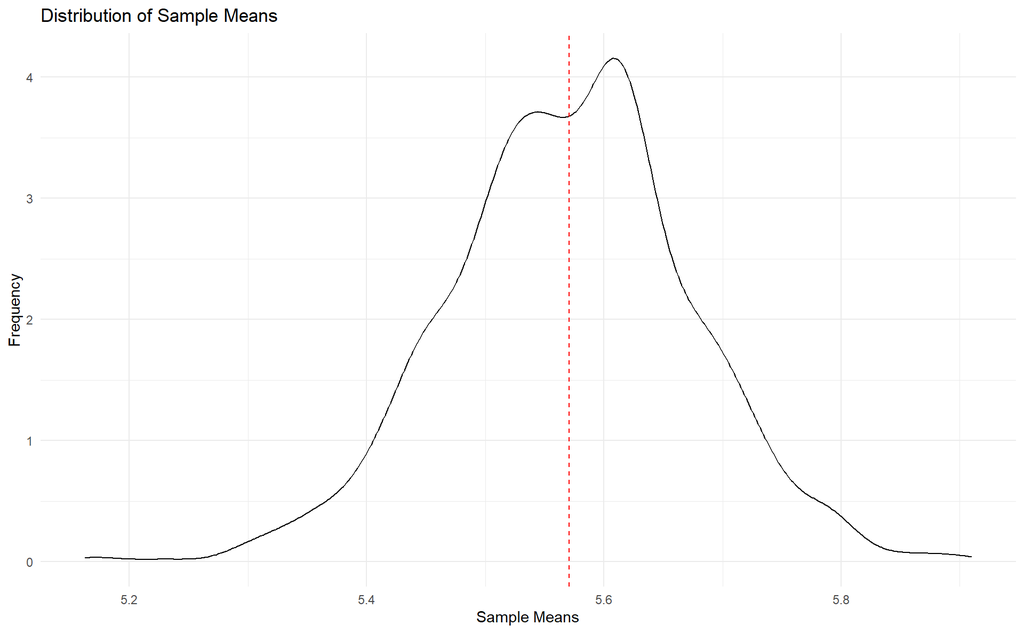

```r
library(tidyverse)

ggplot(as.data.frame(sample_means), aes(sample_means)) +
  #geom_histogram(bins=30)+
  geom_density()+
  geom_vline(xintercept = mean(sample_means),
             color="red", linetype="dashed") +
  labs(title="Distribution of Sample Means",
       x="Sample Means",
       y="Frequency")+
  theme_minimal()
```

## Write a function

- Functions are blocks of code that can be reused
  - they take input arguments
  - they return output
  - they can be used in loops, apply functions, and other functions
  - they can be used to create new variables, summarize data, and run simulations
- the basic structure of a function is:
  - function_name <- function(input arguments) {code to execute}
  - return(output)
- we now touch upon some basics

## functions - basics

- Let us start with a simple function, z-score of a variable

```r
zscore<- function(x) {
  zscore<- (x - mean(x))/sd(x)
  return(zscore)
}

z_income<- zscore(addh$income)

head(z_income, 10)
```

```
 [1]  0.5221372 -0.4693026  0.1243644  0.3847371  1.2013581  0.9246830
 [7] -0.4400798  0.6028251  1.5828892 -0.6833786
```

- more complicated example

```r
sample_means<- function(data, n, reps) {
  sample_means<- numeric(length=reps)

  for (i in seq_along(sample_means)) {
    samp<- sample(data, size = n, replace=TRUE)
    sample_means[i]<- mean(samp)
  }

  return(sample_means)
}
```

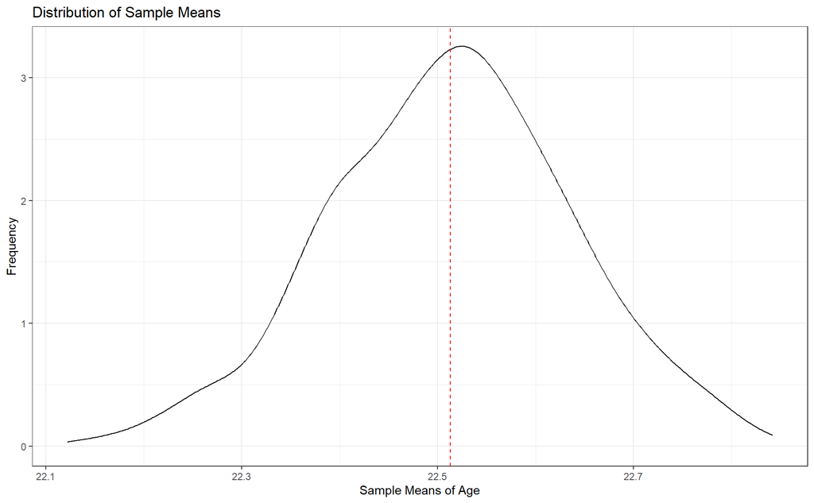

```r
age_sample_means<- sample_means(addh$age, 500, 1000)

ggplot(as.data.frame(age_sample_means), aes(age_sample_means)) +
  geom_density()+
  geom_vline(xintercept = mean(age_sample_means),
             color="red", linetype="dashed") +
  labs(title="Distribution of Sample Means",
       x="Sample Means of Age",
       y="Frequency")+
  theme_bw()
```

## Exercises

- create a function that incorporate both sample means functions and the density plot as above
- plot the distribution of sample means for the variable `love` in the `addh` dataset using the function

## Lists and map functions from `purrr` library

- Lists are a way to store multiple objects in R
  - can store vectors, dataframes, and other lists
  - can store objects of different classes

```r
list1<- list(1, c(8,9,10,11,12), data.frame(x=1:10, y=11:20))

list1
```

```
[[1]]
[1] 1

[[2]]
[1]  8  9 10 11 12

[[3]]
    x  y
1   1 11
2   2 12
3   3 13
4   4 14
5   5 15
6   6 16
7   7 17
8   8 18
9   9 19
10 10 20
```

## Lists and map functions from `purrr` library

- The syntax is `map(mylist, myfunction, functionoptions)` and can change depending on the type of output for your analysis

```r
library(purrr)

map(list1, length)
```

```
[[1]]
[1] 1

[[2]]
[1] 5

[[3]]
[1] 2
```

```r
map(list1, class)
```

```
[[1]]
[1] "numeric"

[[2]]
[1] "numeric"

[[3]]
[1] "data.frame"
```

```r
map(list1, summary)
```

```
[[1]]
   Min. 1st Qu.  Median    Mean 3rd Qu.    Max.
      1       1       1       1       1       1

[[2]]
   Min. 1st Qu.  Median    Mean 3rd Qu.    Max.
      8       9      10      10      11      12

[[3]]
       x               y
 Min.   : 1.00   Min.   :11.00
 1st Qu.: 3.25   1st Qu.:13.25
 Median : 5.50   Median :15.50
 Mean   : 5.50   Mean   :15.50
 3rd Qu.: 7.75   3rd Qu.:17.75
 Max.   :10.00   Max.   :20.00
```

## Tidy approach to data

- The tidy approach (Wickham (2014)) to data is a way to organize data in a consistent format
  - each variable is a column
  - each observation is a row
  - each type of observational unit is a table
  - each value is a cell

## Reshape the data

## let us start from a “real” example

```r
library(tidyr)

sleep_wide<- tibble(name=c("KT", "Olivia", "Dean"),
                    day1=c(8, 7, 6),
                    day2=c(6, 6, 5),
                    day3=c(5, 4, 4))

sleep_wide
```

```
# A tibble: 3 × 4
  name    day1  day2  day3
  <chr>  <dbl> <dbl> <dbl>
1 KT         8     6     5
2 Olivia     7     6     4
3 Dean       6     5     4
```

```r
sleep_long<- sleep_wide %>%
  pivot_longer(cols=day1:day3,
               names_to="day",
               values_to="sleep_hours")



sleep_long
```

```
# A tibble: 9 × 3
  name   day   sleep_hours
  <chr>  <chr>       <dbl>
1 KT     day1            8
2 KT     day2            6
3 KT     day3            5
4 Olivia day1            7
5 Olivia day2            6
6 Olivia day3            4
7 Dean   day1            6
8 Dean   day2            5
9 Dean   day3            4
```

```r
library(stringr)

sleep_long %>%
  mutate(day=stringr::str_sub(day,-1, -1))
```

```
# A tibble: 9 × 3
  name   day   sleep_hours
  <chr>  <chr>       <dbl>
1 KT     1               8
2 KT     2               6
3 KT     3               5
4 Olivia 1               7
5 Olivia 2               6
6 Olivia 3               4
7 Dean   1               6
8 Dean   2               5
9 Dean   3               4
```

## Reshape the data

### from long to wide

```r
sleep_wide2<- sleep_long %>%
  pivot_wider(names_from=day,
              values_from=sleep_hours)

sleep_wide2
```

```
# A tibble: 3 × 4
  name    day1  day2  day3
  <chr>  <dbl> <dbl> <dbl>
1 KT         8     6     5
2 Olivia     7     6     4
3 Dean       6     5     4
```

## Execises

```r
sleep_wide2<- tibble(name=c(rep("KT",2), rep("Olivia",2), rep("Dean",2)),
                     activity=rep(c("sleep", "play"),3),
                     day1=c(8, 2, 7, 2, 5, 3),
                     day2=c(6, 1, 1, 3, 6, 2),
                     day3=c(5, 1, 4, 1, 4, 3))

sleep_wide2
```

```
# A tibble: 6 × 5
  name   activity  day1  day2  day3
  <chr>  <chr>    <dbl> <dbl> <dbl>
1 KT     sleep        8     6     5
2 KT     play         2     1     1
3 Olivia sleep        7     1     4
4 Olivia play         2     3     1
5 Dean   sleep        5     6     4
6 Dean   play         3     2     3
```

- how to express the data in a tidy format?
  - i.e. name, day, sleep, play as columns

```r
sleep_tidy<- sleep_wide2 %>%
  pivot_longer(cols=day1:day3,
               names_to="day",
               values_to="hours") %>%
  mutate(day=stringr::str_sub(day, -1, -1)) %>%
  pivot_wider(names_from=activity,
              values_from=hours)

sleep_tidy
```

```
# A tibble: 9 × 4
  name   day   sleep  play
  <chr>  <chr> <dbl> <dbl>
1 KT     1         8     2
2 KT     2         6     1
3 KT     3         5     1
4 Olivia 1         7     2
5 Olivia 2         1     3
6 Olivia 3         4     1
7 Dean   1         5     3
8 Dean   2         6     2
9 Dean   3         4     3
```

## Export data

- The last step in data analysis is to export the data
  - save the data in a format that can be shared with others
  - save the data in a format that can be read by other software
  - save the data in a format that can be used in other software
- Export command depends on the type of file you are trying to write to
  - write.csv for CSV
  - write.xslx for Excel
  - write.dta for Stata file
  - etc
- By default, the new file will be saved in current working directory
  - If you want to save it elsewhere, need to specify the path

```r
write_csv(sleep_tidy, "sleep_tidy.csv")

library(haven)
write_dta(sleep_tidy, "c:/Users/KT/Downloads/sleep_tidy.dta")
```

## Basic merge

- The typical merge in R is left_join
  - keep all rows from “left” table even if observation doesn’t have matching row in “right” table
  - this will drop observations from the joining data when they are not matched to the “left” table

```r
sleep_tidy<- tibble(name=c("KT", "Olivia", "Dean", "May", "Mary"),
                     sleep=c(8, 7, 6, 5, 5),
                     play=c(2, 2, 3, 3, 2))

sleep_tidy2<- tibble(name=c("KT", "Olivia", "Dean", "Peter", "Susan"),
                      study=c(3, 4, 5, 2, 3),
                      work=c(8, 10, 9, 6, 5))

sleep_tidy3<- left_join(sleep_tidy, sleep_tidy2, by="name")

sleep_tidy3
```

```
# A tibble: 5 × 5
  name   sleep  play study  work
  <chr>  <dbl> <dbl> <dbl> <dbl>
1 KT         8     2     3     8
2 Olivia     7     2     4    10
3 Dean       6     3     5     9
4 May        5     3    NA    NA
5 Mary       5     2    NA    NA
```

```r
sleep_tidy4<- left_join(sleep_tidy2, sleep_tidy, by="name")

sleep_tidy4
```

```
# A tibble: 5 × 5
  name   study  work sleep  play
  <chr>  <dbl> <dbl> <dbl> <dbl>
1 KT         3     8     8     2
2 Olivia     4    10     7     2
3 Dean       5     9     6     3
4 Peter      2     6    NA    NA
5 Susan      3     5    NA    NA
```

## Merge data

- *inner join* Only keep rows of the first data.frame that have corresponding records in the second data.frame

```r
sleep_tidy5<- inner_join(sleep_tidy, sleep_tidy2, by="name", suffix=c("_sleep", "_work"))

sleep_tidy5
```

```
# A tibble: 3 × 5
  name   sleep  play study  work
  <chr>  <dbl> <dbl> <dbl> <dbl>
1 KT         8     2     3     8
2 Olivia     7     2     4    10
3 Dean       6     3     5     9
```

- *full join* Keep all rows from both dataframes, filling in missing values with NAs

```r
sleep_tidy6<- full_join(sleep_tidy, sleep_tidy2, by="name")

sleep_tidy6
```

```
# A tibble: 7 × 5
  name   sleep  play study  work
  <chr>  <dbl> <dbl> <dbl> <dbl>
1 KT         8     2     3     8
2 Olivia     7     2     4    10
3 Dean       6     3     5     9
4 May        5     3    NA    NA
5 Mary       5     2    NA    NA
6 Peter     NA    NA     2     6
7 Susan     NA    NA     3     5
```

Imai, Kosuke, and Nora Webb Williams. 2022. *Quantitative Social Science : An Introduction in Tidyverse*. Princeton, New Jersey: Princeton University Press.

Wickham, Hadley. 2014. “Tidy Data.” *Journal of Statistical Software* 59 (10): 1–23.

———. 2016. *Ggplot2 : Elegrant Graphics for Data Analysis*. Second edition. Use r! Switzerland: Springer.

———. 2019. *Advanced r*. Second edition. The r Series. Boca Raton, FL: CRC Press.

Wickham, Hadley, and Garrett Grolemund. 2023. *R for Data Science : Import, Tidy, Transform, Visualize, and Model Data*. Second edition. Beijing: O’Reilly.